# Story 01 - Overview [Draft Viz]

### Python Imports

```python
import pandas as pd

import io
import requests

import numpy as np
import matplotlib.pyplot as plt

pd.set_option("display.max_columns", 100)
```

### Helper Functions

```python
def sort_by_total(df):
    df['total'] = df.sum(axis=1)
    df.sort_values(by='total',ascending=False,inplace=True)
    df.drop('total', axis=1, inplace=True)
    return df
```

# Viz 1 - Investment, Trade, Debt, Aid

Charts showing:

- Investment (FDI)
- Trade flows
- Debt
- Aid

from various sectors.

- Show the relative importance of Chinese sources of these flows
- Show that sector-wise - the money has focused on extractive sectors

## Data Sources

#### Investment (FDI)

DICA - by country by year

- [dataset 2011 to Dec 2018 in PDF](https://dica.gov.mm/sites/dica.gov.mm/files/document-files/yearly_country.pdf)
- [index](https://dica.gov.mm/en/topic/foreign-investment-country)

DICA - by sector by year

- [dataset 2011 to Dec 2018 in PDF](https://dica.gov.mm/sites/dica.gov.mm/files/document-files/yearly_sector.pdf)
- [index](https://dica.gov.mm/en/topic/foreign-investment-sector)

#### Trade flows

Ministry of Commerce by country by year

- dataset in HTML table

Ministry of Commerce by sector by year

- datast in HTML table

MMSIS exports by commodity by year

- [dataset in data portal - can export CSV](http://mmsis.gov.mm/statHtml/statHtml.do?orgId=195&tblId=DT_YAJ_0001&conn_path=I2)

MMSIS exports by country by year

- [dataset in data portal - can export CSV](http://mmsis.gov.mm/statHtml/statHtml.do?orgId=195&tblId=DT_YAJ_0009&conn_path=I2)

#### Debt

Pyidaungsu Hluttaw - Annual Debt Report

#### Aid

Mohinga.info Aid Transparency Portal

- dataset downloadable from dashboard - aid by country

## Cleaned Data

#### Investment (FDI)

DICA - by country by year

- [dataset 2011 to Dec 2018 in PDF](https://dica.gov.mm/sites/dica.gov.mm/files/document-files/yearly_country.pdf)
- [index](https://dica.gov.mm/en/topic/foreign-investment-country)

Scraped using Tabula

- CSV of cleaned data

```python
investment_country_year_df = pd.read_csv(\
                    "../../data/investment/investment-country-year/tabula-investment_yearly_country_cleaned.csv")
investment_country_year_df.set_index('Country',inplace=True)

investment_country_year_df.head()
```

| Country | Foreign capital to be brought in | 1988-89 to 2010-2011 | 2011-12 | 2012-2013 | 2013-2014 | 2014-2015 | 2015-2016 | 2016-2017 | 2017-2018 | 2018 (4-9) | 2018-2019 (As of 31/12/2018) |
| --- | --- | --- | --- | --- | --- | --- | --- | --- | --- | --- | --- |
| Australia | 145.799 | 82.080 | NaN | NaN | 17.696 | NaN | 29.733 | 16.290 | NaN | NaN | NaN |
| Austria | 74.365 | 72.500 | NaN | NaN | NaN | NaN | NaN | NaN | NaN | 1.865 | NaN |
| Bangladesh | 7.890 | 2.957 | NaN | NaN | NaN | NaN | 2.356 | 1.077 | 1.500 | NaN | NaN |
| Brunei Darussalam | 105.122 | 2.040 | NaN | 1.000 | 2.273 | 43.873 | 26.483 | 18.026 | 8.074 | 3.355 | NaN |
| Canada | 203.594 | 39.781 | NaN | 2.102 | NaN | 153.924 | 1.277 | 5.150 | 1.360 | NaN | NaN |

### Chart: Foreign investment by country

Total investment by country from 1988 to 2018 in USD millions

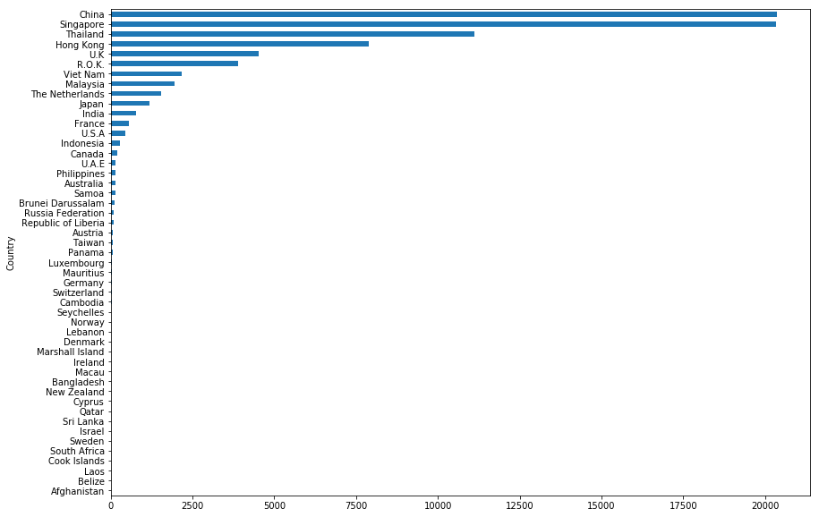

```python
investment_country_year_df['Foreign capital to be brought in'].sort_values(ascending=True) \
                                                                .plot(kind='barh',\
                                                                    figsize=(14, 10))
```

### Chart: Foreign investment by country over 3 seperate time periods

Total investment by country from 1988 to 2011, 2012 to 2015, and 2016 to 2018 in USD millions

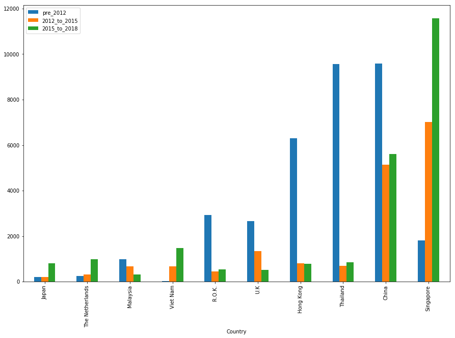

```python
cols_pre_2012 = ['1988-89 to 2010-2011']
cols_2012_to_2015 = ['2011-12','2012-2013','2013-2014','2014-2015']
cols_2015_to_2018 = ['2015-2016','2016-2017','2017-2018','2018 (4-9)','2018-2019 (As of 31/12/2018)']
year_group_col_names = ['pre_2012','2012_to_2015','2015_to_2018']

investment_country_year_grouped_df = pd.DataFrame(columns=year_group_col_names)

investment_country_year_grouped_df['pre_2012'] = investment_country_year_df[cols_pre_2012].sum(axis=1)
investment_country_year_grouped_df['2012_to_2015'] = investment_country_year_df[cols_2013_to_2015].sum(axis=1)
investment_country_year_grouped_df['2015_to_2018'] = investment_country_year_df[cols_2015_to_2018].sum(axis=1)
investment_country_year_grouped_df['total'] = investment_country_year_grouped_df.sum(axis=1)
investment_country_year_grouped_df.sort_values(by='total',ascending=True,inplace=True)

investment_country_year_grouped_df.tail(10)\
    [year_group_col_names].plot(kind='bar',\
                                figsize=(15, 10))
```

DICA - by sector by year

- [dataset 2011 to Dec 2018 in PDF](https://dica.gov.mm/sites/dica.gov.mm/files/document-files/yearly_sector.pdf)
- [index](https://dica.gov.mm/en/topic/foreign-investment-sector)

Scraped using Tabula

- CSV of cleaned data

```python
investment_sector_year_df = pd.read_csv(\
                    "../../data/investment/investment-sector-year/tabula-investment_yearly_sector_cleaned.csv")
investment_sector_year_df.set_index('Country',inplace=True)


investment_sector_year_df.head(20)
```

| Country | Foreign capital to be brought in | 1988-89 to 2010-2011 | 2011-12 | 2012-2013 | 2013-2014 | 2014-2015 | 2015-2016 | 2016-2017 | 2017-2018 | 2018 (4-9) | 2018-2019 (As of 31/12/2018) |
| --- | --- | --- | --- | --- | --- | --- | --- | --- | --- | --- | --- |
| Agriculture | 405.621 | 173.101 | NaN | 9.650 | 20.269 | 39.666 | 7.180 | NaN | 134.485 | 10.650 | 10.620 |
| Livestock and Fisheries | 628.990 | 315.408 | NaN | 5.600 | 96.016 | 26.861 | 8.250 | 96.678 | 27.661 | 32.955 | 19.561 |
| Mining | 2904.916 | 2794.463 | 19.897 | 15.334 | 32.730 | 6.259 | 28.923 | NaN | 1.310 | 6.000 | NaN |
| Manufacturing | 10386.054 | 1738.593 | 32.254 | 400.716 | 1823.882 | 1502.013 | 1069.846 | 1179.514 | 1769.177 | 706.677 | 189.559 |
| Power | 21084.852 | 14523.365 | 4343.978 | 364.201 | 46.511 | 40.110 | 360.100 | 909.883 | 405.774 | 92.680 | NaN |
| Oil and Gas | 22420.572 | 13815.375 | 247.697 | 309.200 | NaN | 3220.306 | 4817.790 | NaN | NaN | NaN | 10.204 |
| Construction | 37.767 | 37.767 | NaN | NaN | NaN | NaN | NaN | NaN | NaN | NaN | NaN |
| Transport and Communication | 9785.256 | 313.272 | 0.634 | NaN | 1190.232 | 1679.304 | 1930.996 | 3081.149 | 901.639 | 314.158 | 415.223 |
| Hotel and Tourism | 3040.684 | 1064.811 | NaN | 300.000 | 435.210 | 357.949 | 288.395 | 403.646 | 176.767 | 9.536 | 4.370 |
| Real Estate | 5256.347 | 1056.453 | NaN | NaN | 440.573 | 780.745 | 728.680 | 747.620 | 1261.977 | 280.380 | NaN |
| Industrial Estate | 271.631 | 193.113 | NaN | NaN | NaN | NaN | 10.000 | NaN | 34.037 | 34.481 | NaN |
| Other Services | 2314.125 | 23.686 | NaN | 14.766 | 18.534 | 357.320 | 235.963 | 231.322 | 1005.259 | 277.184 | 150.091 |

### Chart: Foreign investment by sector

Total investment by sector from 1988 to 2018 in USD millions

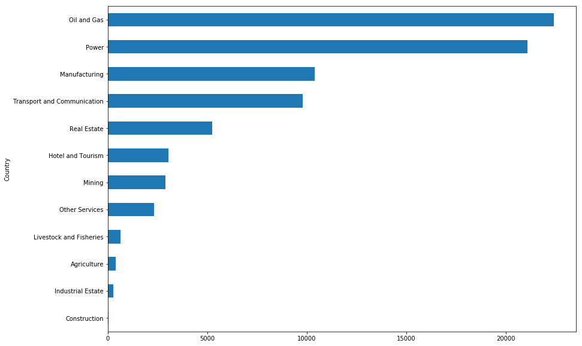

```python
investment_sector_year_df['Foreign capital to be brought in'].sort_values(ascending=True) \
                                                                .plot(kind='barh',\
                                                                    figsize=(14, 10))
```

### Chart: Foreign investment by sector over 3 seperate time periods

Total investment by sector from 1988 to 2011, 2012 to 2015, and 2016 to 2018 in USD millions

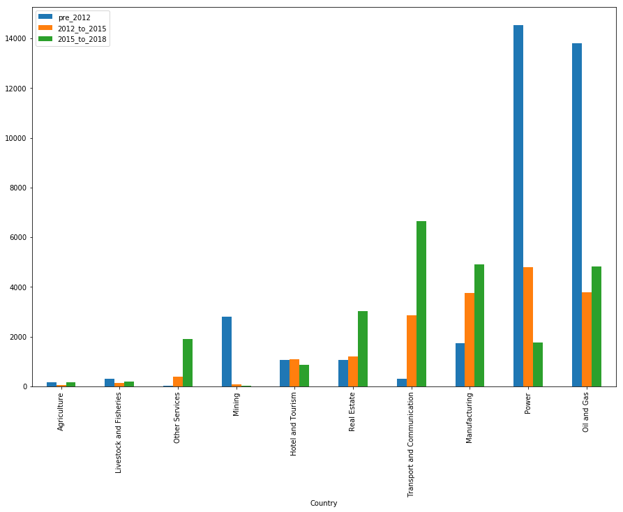

```python
investment_country_sector_grouped_df = pd.DataFrame(columns=year_group_col_names)

investment_country_sector_grouped_df['pre_2012'] = investment_sector_year_df[cols_pre_2012].sum(axis=1)
investment_country_sector_grouped_df['2012_to_2015'] = investment_sector_year_df[cols_2013_to_2015].sum(axis=1)
investment_country_sector_grouped_df['2015_to_2018'] = investment_sector_year_df[cols_2015_to_2018].sum(axis=1)
investment_country_sector_grouped_df['total'] = investment_sector_year_df.sum(axis=1)
investment_country_sector_grouped_df.sort_values(by='total',ascending=True,inplace=True)

investment_country_sector_grouped_df.tail(10)\
    [year_group_col_names].plot(kind='bar',\
                                figsize=(15, 10))
```

#### Trade flows

Ministry of Commerce by country by year

- dataset in HTML table

[Imported and cleaned in Google Sheets](https://docs.google.com/spreadsheets/d/11jyljBYt7Wqbrps9GCdccJCJkvY0X3mJ4IjJllEzhc8/edit?usp=sharing)

[CSV of cleaned data](https://docs.google.com/spreadsheets/d/e/2PACX-1vTC9-izZ5SoG3cWvm08nV4UIvbsBncEefOUuKbXAWvq-f-2G2eayNdL9UdS1B89ObZXi_X0fImJ8Pt5/pub?gid=398138109&single=true&output=csv)

```python
url = "https://docs.google.com/spreadsheets/d/e/2PACX-1vTC9-izZ5SoG3cWvm08nV4UIvbsBncEefOUuKbXAWvq-f-2G2eayNdL9UdS1B89ObZXi_X0fImJ8Pt5/pub?gid=398138109&single=true&output=csv"
s = requests.get(url).content
trade_country_year_df = pd.read_csv(io.StringIO(s.decode('utf-8')))
trade_country_year_df.set_index('COUNTRY',inplace=True)


trade_country_year_df.head()
```

| COUNTRY | 2011-2012_EXPORT | 2011-2013_IMPORT | 2011-2014_TRADE | 2012-2013_EXPORT | 2012-2014_IMPORT | 2012-2015_TRADE | 2013-2014_EXPORT | 2013-2015_IMPORT | 2013-2016_TRADE | 2014-2015_EXPORT | ... | 2016-2019_TRADE | 2017-2018 _EXPORT | 2017-2019_IMPORT | 2017-2020_TRADE | 2018_EXPORT | 2018_IMPORT | 2018_TRADE | 2018-2019 (UP TO FEBRUARY MONTHLY)_EXPORT | 2018-2019 (UP TO FEBRUARY MONTHLY)_IMPORT | 2018-2019 (UP TO FEBRUARY MONTHLY)_TRADE |
| --- | --- | --- | --- | --- | --- | --- | --- | --- | --- | --- | --- | --- | --- | --- | --- | --- | --- | --- | --- | --- | --- |
| AFGHANISTAN | NaN | 1.377 | 1.377 | NaN | 0.115 | 0.115 | NaN | 0.007 | 0.007 | NaN | ... | 4.801 | 17.167 | 0.999 | 18.166 | 0.062 | 0.859 | 0.921 | 0.037 | 0.701 | 0.739 |
| ALBANIA | NaN | NaN | NaN | NaN | NaN | NaN | NaN | NaN | NaN | NaN | ... | 0.175 | NaN | 0.025 | 0.025 | 0.069 | 0.014 | 0.082 | 0.010 | 0.016 | 0.026 |
| ALGERIA | NaN | NaN | NaN | NaN | NaN | NaN | NaN | NaN | NaN | NaN | ... | NaN | 0.059 | 0.002 | 0.061 | 0.033 | NaN | 0.033 | 0.018 | NaN | 0.018 |
| AMERICAN SAMOA | NaN | 0.642 | 0.642 | NaN | 0.030 | 0.030 | NaN | 0.174 | 0.174 | NaN | ... | 1.746 | NaN | 0.275 | 0.275 | NaN | 0.012 | 0.012 | NaN | NaN | NaN |
| ANDORRA | NaN | 0.001 | 0.001 | NaN | NaN | NaN | NaN | NaN | NaN | NaN | ... | 3.802 | 15.531 | 0.058 | 15.589 | 0.808 | 0.007 | 0.815 | NaN | 0.001 | 0.001 |

5 rows × 27 columns

```python
export_cols = [col for col in trade_country_year_df.columns if '_EXPORT' in col]
export_country_year_df = trade_country_year_df.loc[:,export_cols]
export_country_year_df['total'] = export_country_year_df.sum(axis=1)
export_country_year_df.sort_values(by='total',ascending=False,inplace=True)

export_country_year_df.head(20)
```

| COUNTRY | 2011-2012_EXPORT | 2012-2013_EXPORT | 2013-2014_EXPORT | 2014-2015_EXPORT | 2015-2016_EXPORT | 2016-2017 _EXPORT | 2017-2018 _EXPORT | 2018_EXPORT | 2018-2019 (UP TO FEBRUARY MONTHLY)_EXPORT | total |
| --- | --- | --- | --- | --- | --- | --- | --- | --- | --- | --- |
| CHINA | 2214.298 | 2238.070 | 2913.673 | 4692.459 | 4596.961 | 5055.487 | 5699.348 | 2892.497 | 2041.806 | 32344.599 |
| THAILAND | 3823.827 | 4000.576 | 4304.016 | 4031.756 | 2893.180 | 2202.234 | 2846.066 | 1560.502 | 1276.272 | 26938.429 |
| INDIA | 1045.984 | 1018.693 | 1143.399 | 745.804 | 904.163 | 943.476 | 607.253 | 292.032 | 299.336 | 7000.140 |
| JAPAN | 320.201 | 406.487 | 513.245 | 555.678 | 393.753 | 784.257 | 956.032 | 760.976 | 598.248 | 5288.877 |
| SINGAPORE | 542.751 | 291.350 | 694.027 | 758.535 | 725.434 | 472.764 | 753.495 | 190.429 | 101.879 | 4530.664 |
| KOREA, REPUBLIC OF | 214.821 | 280.766 | 352.918 | 369.604 | 259.945 | 342.432 | 303.257 | 230.840 | 233.547 | 2588.130 |
| HONG KONG, CHINA | 41.474 | 12.726 | 489.103 | 288.527 | 282.808 | 204.165 | 363.041 | 230.057 | 51.291 | 1963.192 |
| GERMANY, FEDERAL REPUBLIC OF | 42.329 | 42.979 | 40.361 | 68.094 | 85.040 | 219.742 | 380.060 | 282.822 | 228.945 | 1390.372 |
| MALAYSIA | 152.038 | 97.977 | 108.868 | 264.999 | 161.320 | 159.009 | 222.547 | 121.979 | 91.747 | 1380.484 |
| UNITED STATES OF AMERICA | 29.447 | 2.815 | 24.778 | 50.595 | 69.217 | 192.050 | 286.714 | 293.137 | 232.540 | 1181.293 |
| UNITED KINGDOM | 16.579 | 26.942 | 48.583 | 53.762 | 35.237 | 134.078 | 311.270 | 233.100 | 174.312 | 1033.863 |
| VIET NAM | 81.090 | 81.243 | 111.155 | 80.181 | 56.669 | 88.253 | 127.511 | 133.715 | 85.123 | 844.940 |
| SPAIN | 16.050 | 19.861 | 28.958 | 37.898 | 37.558 | 82.488 | 169.077 | 169.248 | 190.983 | 752.121 |
| NETHERLANDS | 5.655 | 5.250 | 10.755 | 28.186 | 49.235 | 91.757 | 175.800 | 212.986 | 163.285 | 742.909 |
| INDONESIA | 40.936 | 31.538 | 60.040 | 86.045 | 139.836 | 125.046 | 123.909 | 62.822 | 44.859 | 715.031 |
| BANGLADESH | 70.586 | 31.087 | 59.091 | 30.082 | 18.125 | 23.996 | 170.045 | 230.055 | 20.061 | 653.128 |
| UNITED ARAB EMIRATES | 35.294 | 37.550 | 66.033 | 75.023 | 66.690 | 73.359 | 69.476 | 32.162 | 38.799 | 494.386 |
| BELGIUM | 6.744 | 1.486 | 7.030 | 17.712 | 24.246 | 77.565 | 151.175 | 114.890 | 79.815 | 480.663 |
| ITALY | 6.895 | 14.118 | 16.783 | 19.878 | 22.980 | 51.107 | 106.015 | 105.474 | 80.958 | 424.208 |
| FRANCE | 15.746 | 4.106 | 4.998 | 9.638 | 19.192 | 41.631 | 75.209 | 70.678 | 114.547 | 355.745 |

USD millions

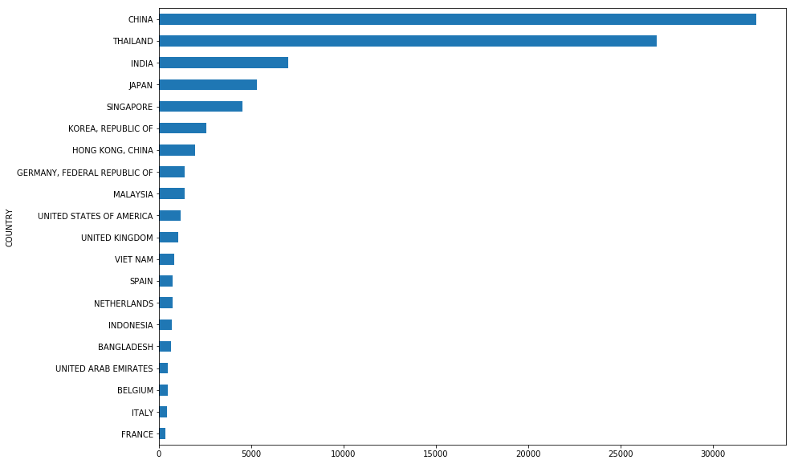

```python
export_country_year_df['total'].head(20).sort_values(ascending=True) \
        .plot(kind='barh',\
            figsize=(14, 10))
```

Ministry of Commerce by sector by year

- datast in HTML table

[Imported and cleaned in Google Sheets](https://docs.google.com/spreadsheets/d/1vCZjj45rrBVD96OaHG2QKhRcMqYkGB_Rqb_ySNXg2L0/edit?usp=sharing)

[CSV of cleaned data](https://docs.google.com/spreadsheets/d/e/2PACX-1vRyjImW7PBNlCkv1CvdQUcQsN2vjCy8xQS6XEsaX9_Z6Kr58PLOS251o4_IF7950IUHev8-xBY7PEHt/pub?gid=398138109&single=true&output=csv)

```python
url = "https://docs.google.com/spreadsheets/d/e/2PACX-1vRyjImW7PBNlCkv1CvdQUcQsN2vjCy8xQS6XEsaX9_Z6Kr58PLOS251o4_IF7950IUHev8-xBY7PEHt/pub?gid=398138109&single=true&output=csv"
s = requests.get(url).content
trade_sector_year_df = pd.read_csv(io.StringIO(s.decode('utf-8')))

trade_sector_year_df.head()
```

|  | SECTOR | FLOW | 2011-2012_NORMAL | 2011-2012_BORDER | 2011-2012_TOTAL | 2012-2013_NORMAL | 2012-2013_BORDER | 2012-2013_TOTAL | 2013-2014_NORMAL | 2013-2014_BORDER | ... | 2016-2017_TOTAL | 2017-2018_NORMAL | 2017-2018_BORDER | 2017-2018_TOTAL | 2018 (Mini Budget)_NORMAL | 2018 (Mini Budget)_BORDER | 2018 (Mini Budget)_TOTAL | 2018-2019 (UP TO FEBRUARY MONTHLY)_NORMAL | 2018-2019 (UP TO FEBRUARY MONTHLY)_BORDER | 2018-2019 (UP TO FEBRUARY MONTHLY)_TOTAL |
| --- | --- | --- | --- | --- | --- | --- | --- | --- | --- | --- | --- | --- | --- | --- | --- | --- | --- | --- | --- | --- | --- |
| 0 | AGRICULTURE PRODUCTS | export | 1517.317 | 855.244 | 2372.561 | 1250.320 | 1446.416 | 2696.736 | 1056.659 | 1604.352 | ... | 2928.097 | 1321.230 | 1765.893 | 3087.123 | 533.869 | 744.889 | 1278.758 | 574.141 | 772.910 | 1347.051 |
| 1 | ANIMALS PRODUCTS | export | 6.673 | 84.016 | 90.689 | 11.356 | 21.531 | 32.887 | 10.599 | 4.821 | ... | 10.627 | 6.844 | 54.152 | 60.996 | 2.858 | 175.465 | 178.323 | 2.510 | 263.411 | 265.921 |
| 2 | MARINE PRODUCTS | export | 451.596 | 254.309 | 705.905 | 372.721 | 251.457 | 624.178 | 205.624 | 310.418 | ... | 581.526 | 252.684 | 446.359 | 699.043 | 126.320 | 171.824 | 298.144 | 134.681 | 226.905 | 361.586 |
| 3 | MINERAL PRODUCTS | export | 113.328 | 784.386 | 897.714 | 83.617 | 315.439 | 399.056 | 724.034 | 615.421 | ... | 1010.783 | 1289.024 | 494.997 | 1784.021 | 777.864 | 271.319 | 1049.183 | 392.728 | 14.710 | 407.438 |
| 4 | FOREST PRODUCTS | export | 629.281 | 12.708 | 641.989 | 586.562 | 9.084 | 595.646 | 916.607 | 31.421 | ... | 247.006 | 209.433 | 2.687 | 212.120 | 94.172 | 1.039 | 95.211 | 74.021 | 0.583 | 74.604 |

5 rows × 29 columns

```python
total_cols = [col for col in trade_sector_year_df.columns if '_TOTAL' in col]
export_sector_year_df = trade_sector_year_df[trade_sector_year_df['FLOW'] == 'export']
export_sector_year_df.set_index('SECTOR', inplace=True)
export_sector_year_df = export_sector_year_df[total_cols]
export_sector_year_df = sort_by_total(export_sector_year_df)
```

### Chart: Exports by sector from 2011 to 2018

Stacked bar chart and grouped bar chart by sector

USD Millions

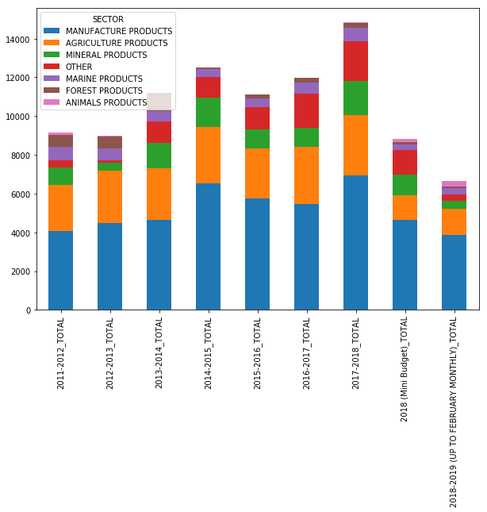

```python
export_sector_year_df.transpose().plot.bar(stacked=True, figsize=(10,7))
```

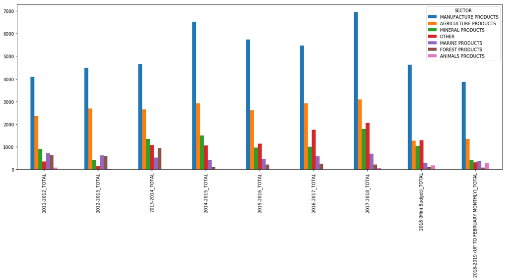

```python
export_sector_year_df.transpose().plot.bar( figsize=(20,7))
```

MMSIS exports by commodity by year

- [dataset in data portal - can export CSV](http://mmsis.gov.mm/statHtml/statHtml.do?orgId=195&tblId=DT_YAJ_0001&conn_path=I2)

CSV of exported data

```python
export_commodity_df = pd.read_csv(\
                    "../../data/trade/mmsis_export_commodity/mmsis_export_by_commodity.csv")
export_commodity_df.set_index('By Commodity Section', inplace=True)
export_commodity_df.replace(['-','#'], 0, inplace=True)
export_commodity_df['2015'] = export_commodity_df['2015'].str.replace('.(r)', '')
export_commodity_df['2015'] = export_commodity_df['2015'].str.replace(')', '')
for c in export_commodity_df.columns:
    export_commodity_df[c] = export_commodity_df[c].astype(float)

export_commodity_df.drop('GRAND TOTAL', axis=0, inplace=True)

export_commodity_df = sort_by_total(export_commodity_df)

export_commodity_df.head()
```

| By Commodity Section | 2001 | 2002 | 2003 | 2004 | 2005 | 2006 | 2007 | 2008 | 2009 | 2010 | 2011 | 2012 | 2013 | 2014 | 2015 | 2016 | 2017 (p) |
| --- | --- | --- | --- | --- | --- | --- | --- | --- | --- | --- | --- | --- | --- | --- | --- | --- | --- |
| Miscellaneous manufactured articles. | 372.70 | 581.25 | 347.36 | 471.62 | 566.63 | 781.90 | 987.28 | 1503.76 | 1110.69 | 1648.85 | 2030.75 | 2196.26 | 3719.56 | 5227.04 | 5130.84 | 5214.58 | 6281.26 |
| Mineral products | 664.94 | 942.30 | 581.60 | 1046.60 | 1141.91 | 2098.63 | 2599.51 | 2427.06 | 2980.08 | 2525.44 | 3508.46 | 3675.47 | 3557.89 | 3859.27 | 2563.88 | 1777.07 | 2148.27 |
| Vegetable products | 428.21 | 414.01 | 374.81 | 306.59 | 401.71 | 681.52 | 818.10 | 1024.50 | 1242.33 | 1070.71 | 1381.24 | 1158.65 | 981.40 | 1197.37 | 1182.96 | 1351.46 | 1248.39 |
| Textiles and textile articles | 452.99 | 461.40 | 339.47 | 223.70 | 277.27 | 285.89 | 287.38 | 296.99 | 289.25 | 386.91 | 501.64 | 701.25 | 899.47 | 1046.38 | 913.88 | 1948.45 | 2617.26 |
| Wood and articles of wood; wood charcoal;cork and articles of cork; manufactures of straw, of esparto or of other plaiting materials; basketware and wicker-work. | 344.25 | 337.05 | 363.56 | 413.53 | 496.10 | 539.54 | 564.71 | 432.37 | 516.14 | 617.32 | 627.23 | 584.80 | 914.18 | 88.16 | 206.78 | 241.04 | 207.23 |

### Chart: Exports by commodity section

USD Millions

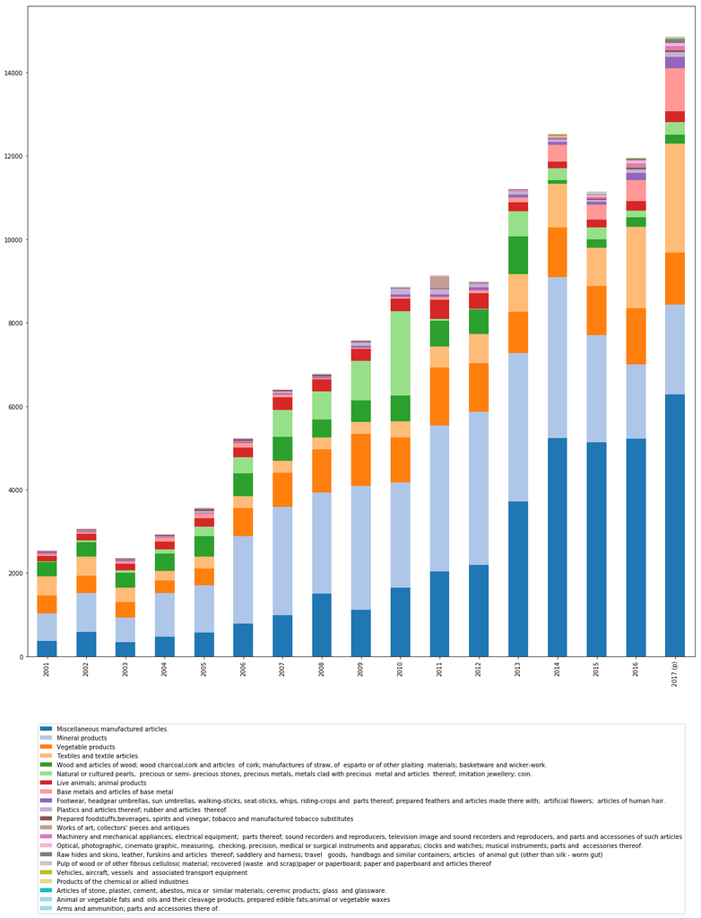

```python
export_commodity_df.transpose().plot.bar(stacked=True, figsize=(20,20), cmap=plt.get_cmap('tab20'))\
    .legend(loc='lower center', bbox_to_anchor=(0.5, -0.4))
```

MMSIS exports by country by year

- [dataset in data portal - can export CSV](http://mmsis.gov.mm/statHtml/statHtml.do?orgId=195&tblId=DT_YAJ_0009&conn_path=I2)

CSV of exported data

```python
export_country_df = pd.read_csv(\
                    "../../data/trade/mmsis_export_country/mmsis_export_by_country.csv")
export_country_df.rename({"By Classification(1)": "Region", \
                          "By Classification(2)": "Country"},axis='columns',inplace=True)
export_country_df['Country'] = export_country_df['Country'].fillna('Total')
export_country_df.set_index(['Region','Country'],inplace=True)

export_country_df.replace(['-','#'], 0, inplace=True)
for c in export_country_df.columns:
    export_country_df[c] = export_country_df[c].str.replace('r', '')
    export_country_df[c] = export_country_df[c].str.replace('(', '')
    export_country_df[c] = export_country_df[c].str.replace(')', '')
    export_country_df[c] = pd.to_numeric(export_country_df[c], errors='coerce')
    export_country_df[c].fillna(0,inplace=True)
    export_country_df[c] = export_country_df[c].astype(float)

export_country_df.drop('Total', level=1, axis=0, inplace=True)

export_country_df = sort_by_total(export_country_df)
export_region_df = sort_by_total(export_region_df)

display(export_region_df.head())
display(export_country_df.head())
```

| Region | Country | 1985 | 1990 | 1995 | 1999 | 2000 | 2001 | 2002 | 2003 | 2004 | 2005 | 2006 | 2007 | 2008 | 2009 | 2010 | 2011 | 2012 | 2013 | 2014 | 2015 | 2016 | 2017 (p) |
| --- | --- | --- | --- | --- | --- | --- | --- | --- | --- | --- | --- | --- | --- | --- | --- | --- | --- | --- | --- | --- | --- | --- | --- |
| REST OF ASIA | Total | 1058.61 | 241.32 | 378.09 | 3390.84 | 701.99 | 5439.93 | 6856.76 | 5540.28 | 1007.71 | 1378.56 | 2096.83 | 2504.10 | 2489.63 | 2930.33 | 4501.74 | 3930.99 | 4012.96 | 5513.57 | 6715.55 | 6502.36 | 7461.27 | 8249.13 |
| SOUTH EAST ASIA | Total | 742.40 | 205.11 | 374.44 | 1932.32 | 513.11 | 7694.42 | 8922.88 | 6265.30 | 1604.79 | 1833.97 | 2791.29 | 3504.96 | 3853.71 | 4158.84 | 3930.84 | 4676.69 | 4529.69 | 5297.53 | 5233.79 | 3985.40 | 3091.64 | 4097.43 |
| NORTH WEST EUROPE | Total | 301.46 | 14.74 | 24.75 | 401.66 | 98.50 | 919.75 | 858.76 | 831.52 | 107.01 | 166.96 | 160.96 | 156.26 | 128.51 | 102.60 | 92.47 | 104.10 | 94.40 | 124.96 | 225.24 | 242.89 | 630.28 | 1247.24 |
| AMERICA | Total | 50.51 | 3.10 | 46.33 | 625.83 | 261.58 | 1970.24 | 2202.57 | 659.90 | 13.91 | 35.59 | 23.42 | 19.60 | 16.90 | 11.52 | 16.22 | 51.43 | 47.01 | 51.84 | 82.63 | 135.60 | 289.61 | 389.94 |
| SOUTHERN EUROPE | Total | 4.69 | 0.12 | 3.08 | 119.03 | 50.88 | 510.49 | 521.46 | 529.01 | 122.03 | 48.59 | 52.43 | 48.21 | 39.33 | 37.13 | 39.97 | 38.45 | 40.08 | 61.71 | 62.96 | 69.99 | 143.99 | 309.09 |

| Region | Country | 1985 | 1990 | 1995 | 1999 | 2000 | 2001 | 2002 | 2003 | 2004 | 2005 | 2006 | 2007 | 2008 | 2009 | 2010 | 2011 | 2012 | 2013 | 2014 | 2015 | 2016 | 2017 (p) |
| --- | --- | --- | --- | --- | --- | --- | --- | --- | --- | --- | --- | --- | --- | --- | --- | --- | --- | --- | --- | --- | --- | --- | --- |
| SOUTH EAST ASIA | Thailand | 134.67 | 62.42 | 95.14 | 552.54 | 281.95 | 5391.81 | 7095.55 | 4676.11 | 1270.62 | 1360.95 | 2362.44 | 2809.65 | 2631.23 | 3215.68 | 2905.18 | 3823.83 | 4000.57 | 4306.28 | 4028.69 | 2893.18 | 2202.24 | 2846.41 |
| REST OF ASIA | China,People's Rep.of | 165.28 | 63.76 | 34.70 | 846.99 | 175.98 | 1545.17 | 3070.48 | 1343.24 | 290.90 | 366.95 | 615.13 | 697.68 | 617.67 | 617.16 | 1203.56 | 2214.30 | 2238.07 | 2910.75 | 4673.87 | 4596.96 | 5055.47 | 5698.66 |
|  | India | 188.90 | 84.34 | 184.37 | 1345.95 | 261.99 | 2323.64 | 2107.84 | 2166.50 | 341.43 | 488.97 | 733.91 | 727.25 | 803.83 | 1013.14 | 871.59 | 1045.99 | 1018.62 | 1143.59 | 745.80 | 904.16 | 943.48 | 607.72 |
| SOUTH EAST ASIA | Singapore | 353.30 | 136.08 | 175.49 | 812.92 | 113.51 | 1099.54 | 881.95 | 785.99 | 141.83 | 262.85 | 182.59 | 400.56 | 832.75 | 670.41 | 456.99 | 542.75 | 291.35 | 694.03 | 758.83 | 725.43 | 472.84 | 753.50 |
| REST OF ASIA | Hong Kong | 329.41 | 39.91 | 63.91 | 427.74 | 81.80 | 377.22 | 389.45 | 475.46 | 114.62 | 255.42 | 401.62 | 647.89 | 673.43 | 947.70 | 1894.69 | 41.47 | 12.73 | 489.10 | 288.60 | 282.81 | 204.16 | 363.04 |

### Chart: Exports by region of world

USD Millions

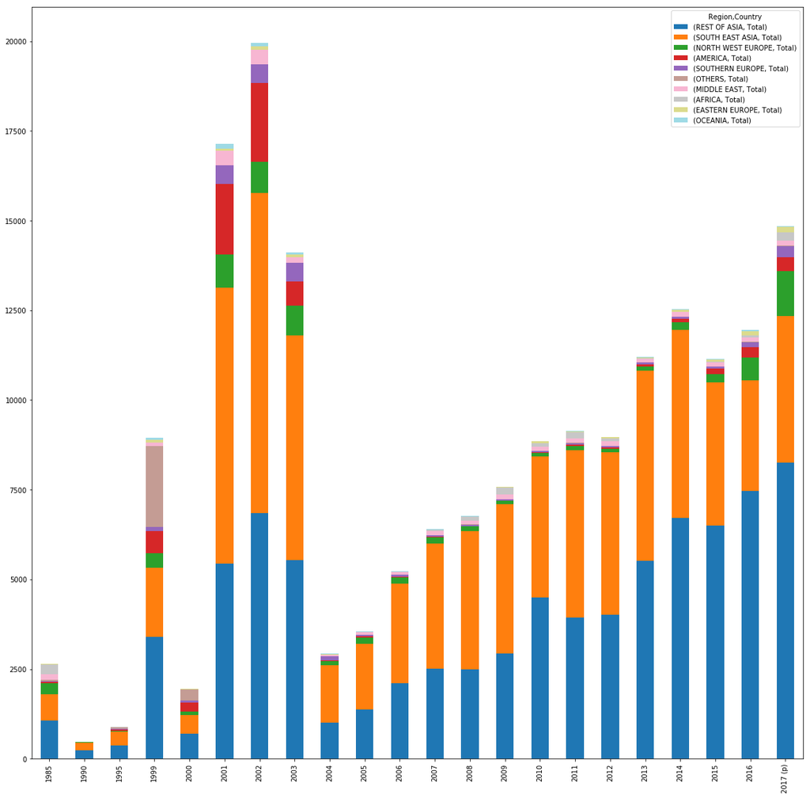

```python
export_region_df.transpose().plot.bar(stacked=True, figsize=(20,20), cmap=plt.get_cmap('tab20'))
```

### Chart: Exports by country

USD Millions

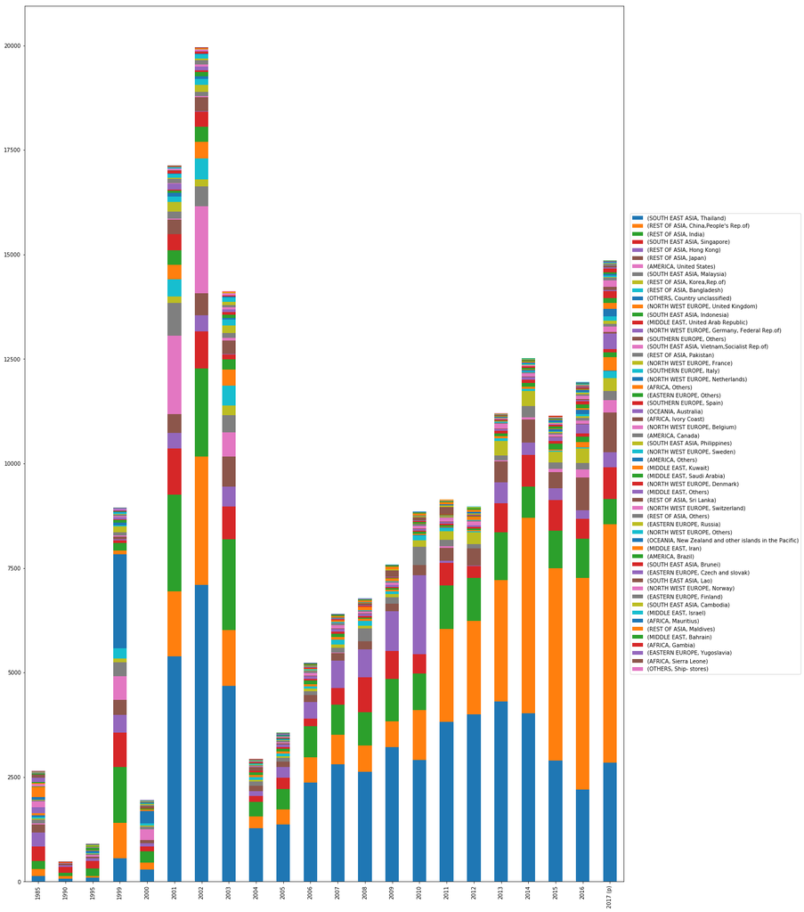

```python
export_country_df

export_country_df.transpose().plot.bar(stacked=True, figsize=(20,30))\
    .legend(loc='right', bbox_to_anchor=(1.3, 0.5))
```

#### Debt

Pyidaungsu Hluttaw - Annual Debt Report

[CSV of exported data](https://docs.google.com/spreadsheets/d/e/2PACX-1vSXx_1j7z_6rSPvq4hkj9mXfT4kwsOOmGtOkp3_YaZJzWqf65yNwDEp6smOfYNnf7q9Xohm4Z3_V6pN/pub?gid=1649083129&single=true&output=csv)

```python
url = "https://docs.google.com/spreadsheets/d/e/2PACX-1vSXx_1j7z_6rSPvq4hkj9mXfT4kwsOOmGtOkp3_YaZJzWqf65yNwDEp6smOfYNnf7q9Xohm4Z3_V6pN/pub?gid=1649083129&single=true&output=csv"
s = requests.get(url).content
debt_country_df = pd.read_csv(io.StringIO(s.decode('utf-8')))
debt_country_df.set_index('Name',inplace=True)
for c in ['Value of debt','Amount withdrawn','Amount repaid','Remaining unpaid']:
    debt_country_df[c] = debt_country_df[c].str.replace(',', '')
    debt_country_df[c] = pd.to_numeric(debt_country_df[c], errors='coerce')
    debt_country_df[c].fillna(0,inplace=True)
    debt_country_df[c] = debt_country_df[c].astype(float)


debt_country_df
```

| Name | Number | Type | Paris club member | Value of debt | Amount withdrawn | Amount repaid | Remaining unpaid |
| --- | --- | --- | --- | --- | --- | --- | --- |
| ADB | 1 | International Organisations | NaN | 1420.390 | 843.443 | 270.936 | 572.507 |
| AIF | 2 | International Organisations | NaN | 20.000 | 1.464 | 0.000 | 1.464 |
| IDA | 3 | International Organisations | NaN | 3410.440 | 1714.790 | 517.006 | 1197.790 |
| IFAD | 4 | International Organisations | NaN | 76.595 | 6.269 | 0.000 | 6.269 |
| OPEC | 5 | International Organisations | NaN | 32.300 | 23.177 | 13.199 | 9.978 |
| Japan | 6 | National government | Yes | 6891.010 | 2476.200 | 0.948 | 2475.260 |
| Australia | 7 | National government | Yes | 139.422 | 139.422 | 0.000 | 139.422 |
| Finland | 8 | National government | Yes | 3.093 | 3.093 | 0.000 | 3.093 |
| France | 9 | National government | Yes | 578.569 | 578.569 | 42.269 | 536.300 |
| Germany | 10 | National government | Yes | 1038.050 | 1002.240 | 207.436 | 794.802 |
| Italy | 11 | National government | Yes | 24.796 | 0.000 | 0.000 | 0.000 |
| Netherlands | 12 | National government | Yes | 9.576 | 9.576 | 0.000 | 9.576 |
| United Kingdom | 13 | National government | Yes | 38.227 | 38.227 | 0.000 | 38.227 |
| AFD | 14 | National government | Yes | 80.587 | 0.000 | 0.000 | 0.000 |
| China | 15 | National government | No | 5781.030 | 5118.350 | 1115.930 | 4002.420 |
| India | 16 | National government | No | 563.898 | 314.235 | 110.233 | 204.002 |
| South Korea | 17 | National government | No | 558.385 | 206.333 | 60.081 | 146.252 |
| Saudi Arabia | 18 | National government | No | 8.000 | 2.530 | 1.000 | 1.530 |
| Thailand | 19 | National government | No | 27.906 | 27.906 | 6.977 | 20.929 |
| Serbia | 20 | National government | No | 70.548 | 70.548 | 30.865 | 39.683 |
| Poland | 21 | National government | No | 61.990 | 0.674 | 0.000 | 0.674 |

### Chart: Total Remaining Debt by country

USD Millions

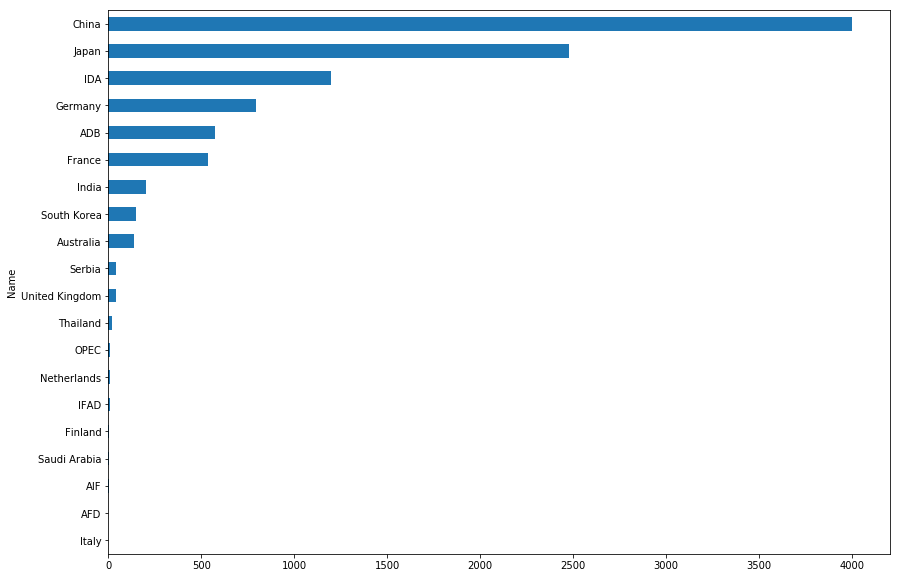

```python
debt_country_df['Remaining unpaid'].head(20).sort_values(ascending=True) \
        .plot(kind='barh',\
            figsize=(14, 10))
```

#### Aid

Mohinga.info Aid Transparency Portal

- dataset downloadable from dashboard - aid by country

XLS of exported data

CSV of exported data

```python
aid_activities_df = pd.read_csv(\
                    "../../data/aid/mohinga_activities/activities_2019_05_02.csv")

aid_activities_df.head()
```

|  | id | Title | Description | Objective | Sector | Coordination Bodies | Status | Collaboration Type | Aid Type Categories | Finance Types | Total Commitment | Total Disbursement | Total Commitment USD | Total Disbursement USD | Transaction count | Filtered Commitment USD | Filtered Disbursement USD | Filtered Transaction count | Reporting Organisation | Financing | Extending | Implementing | Partner Ministry | State/Region | Township | Planned Start date | Planned End date | Actual Start date | Actual End date | … |
| --- | --- | --- | --- | --- | --- | --- | --- | --- | --- | --- | --- | --- | --- | --- | --- | --- | --- | --- | --- | --- | --- | --- | --- | --- | --- | --- | --- | --- | --- | --- |
| 0 | MM-FERD-ID2640 | Supporting Transition by Reducing Food Insecur... | 1.Prepare for and respond to recurrent natural... | 1.Prepare for and respond to recurrent natural... | Basic nutrition(16.60%),Health education(16.60... | Agriculture and Rural Development Sector Coord... | Implementation | Multilateral | Project-type interventions | Grant | 3.414024e+08 | 6.520446e+09 | 3.414024e+08 | 1.822940e+08 | 6241 | 3.414024e+08 | 1.822940e+08 | 79 | World Food Programme | XX - Multiple Donors\| UK - Department for Inte... | World Food Programme | XX - Local NGOs and Civil Society Groups | Ministry of Education\| Ministry of Social Welf... | Yangon Region - 2.00% \| Shan State - 15.00% \| ... | NaN | 2013-01-01 | 2017-12-31 | 2013-01-01 | NaN | … |
| 1 | MM-FERD-ID1048 | Three Millennium Development Goal Fund (3MDG) | NaN | NaN | Basic health care | Health Sector Coordination Group | Implementation | Multilateral | Core contributions and pooled programmes and f... | Grant | 1.880060e+07 | 3.746648e+08 | 1.880060e+07 | 2.621442e+08 | 2025 | 1.880060e+07 | 2.621442e+08 | 45 | United Nations Office for Project Services | UK - Department for International Development\|... | United Nations Office for Project Services | The Three Millennium Development Goal Fund | Ministry of Health and Sports | Nation-wide - 100.00% | NaN | 2013-01-01 | 2018-12-31 | 2013-01-01 | 2018-12-31 | … |
| 2 | MM-FERD-ID1234 | Support for Myanmar's Reforms for Inclusive Gr... | The policy-based loan will support Myanmar's r... | NaN | Public sector financial management | Macroeconomic Management Sector Coordination G... | Completion | Multilateral | Project-type interventions | Loan | 5.755000e+08 | 5.115294e+08 | 5.755000e+08 | 5.115294e+08 | 121 | 5.755000e+08 | 5.115294e+08 | 11 | Asian Development Bank | Asian Development Bank | Ministry of Planning and Finance | Ministry of Education\| Ministry of Commerce\| M... | Ministry of Planning and Finance | Nation-wide - 100.00% | NaN | 2013-01-14 | 2013-01-18 | 2013-01-27 | NaN | … |
| 3 | MM-FERD-ID6903 | National Electrification Project | The project development objective is to help i... | The project development objective is to help i... | Power generation/renewable sources(12.00%),Ele... | Energy and Electric Power Sector Coordination ... | Pipeline/identification | Multilateral | Budget support | Loan | 4.000000e+08 | 7.326139e+07 | 4.000000e+08 | 7.326139e+07 | 576 | 4.000000e+08 | 7.326139e+07 | 24 | World Bank | World Bank | Ministry of Planning and Finance | Ministry of Planning and Finance | Ministry of Electricity and Energy\| Ministry o... | Nation-wide - 100.00% | NaN | 2015-05-28 | 2021-09-30 | 2015-09-16 | NaN | … |
| 4 | MM-FERD-ID1 | Social and Economic Development Support Program | Program Loan is rendered in light of supportin... | Since March 2011, after the inauguration of th... | Multisector aid for basic social services | None | Completion | Bilateral | Project-type interventions | Loan | 1.988800e+11 | 1.988800e+11 | 2.237549e+09 | 2.237549e+09 | 4 | 2.237549e+09 | 2.237549e+09 | 2 | Government of Japan | Government of Japan | NaN | Ministry of Planning and Finance | Ministry of Planning and Finance | Nation-wide - 100.00% | NaN | 2013-01-30 | 2013-05-26 | 2013-01-15 | NaN | … |

```python
aid_activities_pivot_source_df = pd.pivot_table(aid_activities_df,index='Reporting Organisation', \
                    values=['Total Commitment USD','Total Disbursement USD'],\
                    aggfunc=np.sum)

aid_activities_pivot_source_df.sort_values(by='Total Commitment USD',ascending=False,inplace=True)
```

```python
aid_activities_pivot_source_df
```

| Reporting Organisation | Total Commitment USD | Total Disbursement USD |
| --- | --- | --- |
| Government of Japan | 6.318789e+09 | 3.339751e+09 |
| World Bank | 1.346259e+09 | 6.987312e+08 |
| Asian Development Bank | 1.337540e+09 | 6.208963e+08 |
| UK - Department for International Development | 7.958135e+08 | 3.267085e+08 |
| European Union | 6.152000e+08 | 4.396974e+08 |
| Korea EximBank | 5.429750e+08 | 0.000000e+00 |
| U.S. Agency for International Development | 3.778102e+08 | 2.289060e+08 |
| United Nations Children's Fund | 3.537618e+08 | 3.077945e+08 |
| World Food Programme | 3.422056e+08 | 1.822940e+08 |
| Government of France | 2.479403e+08 | 9.034698e+06 |
| Gesellschaft für Internationale Zusammenarbeit | 1.775798e+08 | 4.114928e+07 |
| Swiss Agency for Development and Cooperation | 1.719538e+08 | 8.782465e+07 |
| KfW Entwicklungsbank | 1.699814e+08 | 3.464717e+07 |
| Government of Norway | 1.663954e+08 | 1.290787e+08 |
| Government of India | 1.348600e+08 | 5.000000e+06 |
| United Nations Office for Project Services | 1.200009e+08 | 2.650077e+08 |
| United Nations Development Programme | 1.095700e+08 | 8.168226e+07 |
| Government of Denmark | 1.053187e+08 | 7.581486e+07 |
| Korea International Cooperation Agency | 1.025957e+08 | 2.000000e+06 |
| Government of Germany | 9.832506e+07 | 8.260021e+07 |
| Embassy of Sweden / Section Office Yangon | 8.556883e+07 | 7.293477e+07 |
| DFAT - Australian Aid Program | 7.691533e+07 | 4.225012e+07 |
| Global Affairs Canada | 7.448477e+07 | 5.698851e+07 |
| Government of China | 6.726047e+07 | 6.350000e+06 |
| International Fund for Agricultural Development | 4.859133e+07 | 0.000000e+00 |
| Government of Italy | 4.570950e+07 | 1.773829e+07 |
| United Nations Population Fund | 3.713255e+07 | 1.389660e+07 |
| United Nations Human Settlements Programme | 3.682408e+07 | 3.147708e+07 |
| New Zealand Aid Programme | 3.595393e+07 | 2.588256e+07 |
| Government of Finland | 3.370756e+07 | 2.587502e+07 |
| Government of the Netherlands | 3.275891e+07 | 2.201708e+07 |
| International Labour Organisation | 2.557529e+07 | 7.900000e+05 |
| Office of the United Nations High Commissioner for Refugees | 2.408284e+07 | 0.000000e+00 |
| Asian Infrastructure Investment Bank | 2.000000e+07 | 0.000000e+00 |
| World Health Organisation | 1.926365e+07 | 1.589520e+07 |
| United Nations Educational, Scientific and Cultural Organisation | 1.611673e+07 | 2.454293e+06 |
| Global Fund to Fight AIDS, Tuberculosis and Malaria | 1.540643e+07 | 0.000000e+00 |
| Food and Agriculture Organization | 1.393303e+07 | 0.000000e+00 |
| International Organisation for Migration | 7.899350e+06 | 3.058360e+05 |
| United Nations Industrial Development Organisation | 7.749248e+06 | 0.000000e+00 |
| International Monetary Fund | 7.662000e+06 | 0.000000e+00 |
| Government of Luxembourg | 7.080731e+06 | 1.786506e+05 |
| International Trade Centre | 3.513750e+06 | 2.538750e+06 |
| Kuwait Fund for Arab Economic Development | 2.887000e+06 | 0.000000e+00 |
| International Finance Corporation | 2.000000e+06 | 0.000000e+00 |
| Government of Indonesia | 2.000000e+06 | 0.000000e+00 |
| Agence Française de Développement | 1.892531e+06 | 9.661262e+05 |
| International Atomic Energy Agency | 1.617282e+06 | 8.398912e+05 |
| Humanitarian Aid Office of the European Commission | 1.437053e+06 | 0.000000e+00 |
| Austrian Development Agency | 2.641478e+05 | 0.000000e+00 |
| Global Environment Facility | 1.200000e+05 | 0.000000e+00 |
| Brazilian Cooperation Agency | 1.100000e+05 | 0.000000e+00 |
| Government of Belgium | 1.028430e+05 | 0.000000e+00 |
| Irish Aid | 6.795094e+04 | 0.000000e+00 |
| Government of Singapore | 6.352403e+04 | 0.000000e+00 |
| Government of Poland | 1.587400e+04 | 1.587400e+04 |
| Government of Turkey | 1.000000e+00 | 0.000000e+00 |
| Government of Malaysia | 0.000000e+00 | 0.000000e+00 |

### Chart: Total Development Assistance by Country or Organisation

USD

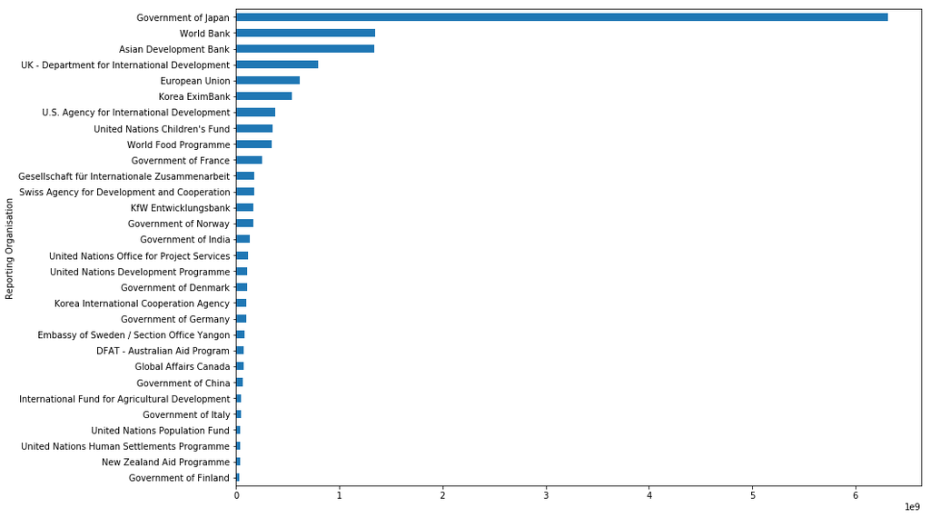

```python
aid_activities_pivot_source_df['Total Commitment USD'].head(30).sort_values(ascending=True) \
        .plot(kind='barh',\
            figsize=(14, 10))
```

# Viz 2 - Location of investments/projects

Show available locations for foreign investment led projects in:

- Dams
- Mines
- Oil and Gas
- Power

## Data Sources

#### Dams

IFC Report on Hydropower in Myanmar

- [Original source - report and dataset](https://www.ifc.org/wps/wcm/connect/industry_ext_content/ifc_external_corporate_site/hydro+advisory/resources/sea+of+the+hydropower+sector+in+myanmar+resources+page)
- [Republished with geocoding from Open Dev MM](https://opendevelopmentmyanmar.net/dataset/?id=myanmar-dams&search_query=P3R5cGU9ZGF0YXNldCZ0YXhvbm9teT1hbGwmc29ydGluZz1tZXRhZGF0YV9jcmVhdGVkJnF1ZXJ5PQ==)

#### Mines

EITI

- [PDFs and Excel data for MEITI Reports](https://myanmareiti.org/en/publication-category/meiti-reports)

#### Oil and Gas

EITI

- [PDFs and Excel data for MEITI Reports](https://myanmareiti.org/en/publication-category/meiti-reports)

#### Power

Ministry of Electricity and Energy State/Region profiles

- [data on power plants spread across multiple HTML pages](http://www.moee.gov.mm/en/ignite/page/46)

# Viz 3 - Regional development indicators

Show disparaties in regional development through these indicators

- Electrification
- Employment
- Poverty, deprivation

These indicators are chosen because they are the most directly linkable to investment projects. We want to counter the govt's line that investment brings development.

## Data Sources

#### Electrification

Ministry of Electricity and Energy State/Region profiles

- [data on power plants spread across multiple HTML pages](http://www.moee.gov.mm/en/ignite/page/46)

#### Employment

2014 Census data on labor

- [PDF of thematic report on labor force - contains aggregated tables](https://myanmar.unfpa.org/en/publications/thematic-report-labour-force)
- [REDATUM Online tool to extract census data](http://www.dopredatam.gov.mm/)

#### Poverty, Deprivation

World Bank - Multidimensional Welfare in Myanmar Report

- [PDF Report](http://documents.worldbank.org/curated/en/593661543241844346/Main-Report)

The WB report does not provide the raw data - but it is all derived from census data. We can look at the criteria that they consider constitutes deprivation to recalculate using census data

# Viz 4 - Conflict and land seizures

Show that locations of conflicts and armed groups are usually in areas where investment projects are located

- Locations of conflict
- Locations of armed groups

Show that we are at the precipice of an even more precarious situation for land seisures with the new VFV law

- VFV and potential for land seizures (contestation of land)

## Data Sources

#### Locations of conflict

Data from ACLED and TAF

- [Google Drive folder of Eva's analysis](https://drive.google.com/open?id=1eNEPWvPH1llhbKQdAfNIj1ecpwOb1FqZ)
- [Original ACLED Source](https://www.acleddata.com/data/)

MIPS Annual Peace and Security Review

- [PDF Report](http://mips-mm.org/annual-peace-security-review-2018/)

#### Locations of armed groups

Asia Foundation's Contested Areas of Myanmar Report

- [PDF Report - map on pg 27](https://asiafoundation.org/publication/contested-areas-myanmar-subnational-conflict-aid-development/) - note: this does not include militias or border guard forces

#### VFV and potential for land seizures (contestation of land)

Mekong Regional Land Governance - Large-Scale Land Acquisitions for Agricultural Development in Myanmar: A Review of Past and Current Processes Report

- [PDF Report contains state/region level data - table 4 on pg 40](https://mrlg.org/resources/large-scale-land-acquisitions-for-agricultural-development-in-myanmar-a-review-of-past-and-current-processes/)

GAD's Township profiles has township level land use data

- [PDFs of township profiles collected by MIMU](http://themimu.info/township-profiles)